# Software Bug Prediction

### K-Nearest Neighbor

```python
knn_params = {
    'clf__n_neighbors': [3, 5, 11, 17], # Try not to put even numbers
    'clf__weights': ['uniform', 'distance'],
    'clf__metric': ['euclidean', 'manhattan'],
}

knn = Modeler(KNeighborsClassifier, X_train_scaled, y_train, X_cv, y_cv, knn_params, scale=True)
```

```
Best Parameters for model: {'metric': 'euclidean', 'n_neighbors': 11, 'weights': 'distance'}
```

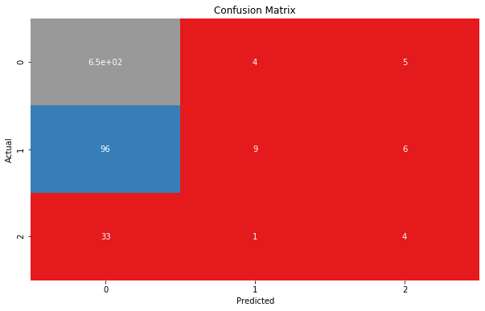

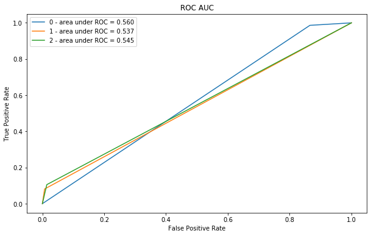

```python
model_scoring = model_eval(knn["model"], X_test_scaled, y_test)
scores["K-Nearest Neighbor | Multi"] = {"Accuracy": model_scoring[0],
                             "ROC": model_scoring[1],
                             "F1-Score": model_scoring[2]}
```

```python
kmeans_params = {
    'clf__max_iter': [200, 500, 1000], # Try not to put even numbers
    'clf__n_init': [10, 30]
}

kmeans = Modeler(KMeans, X_train_scaled, y_train, X_cv, y_cv, kmeans_params, scale=True)
```

```
Best Parameters for model: {'max_iter': 200, 'n_init': 10}
```

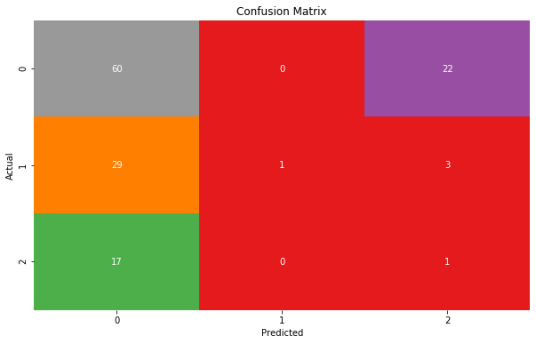

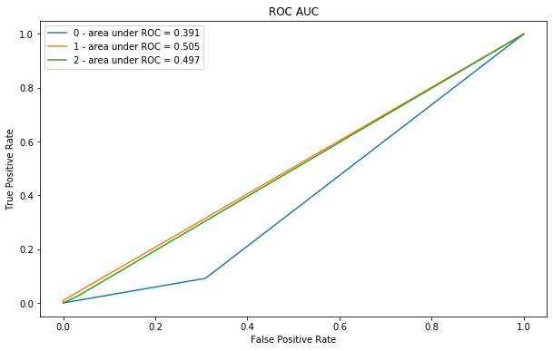

```python
model_scoring = model_eval(kmeans["model"], X_test_scaled, y_test)
scores["K-Means | Multi"] = {"Accuracy": model_scoring[0],
                             "ROC": model_scoring[1],
                             "F1-Score": model_scoring[2]}
```

### Bagging Classifier (Extra for multi-class)

```python
bagg_params = {
    'clf__max_samples': [0.3, 0.5, 0.7, 1.0],
    'clf__bootstrap': [True, False],
    'clf__bootstrap_features': [True, False]
}

bagg = Modeler(BaggingClassifier, X_train_scaled, y_train, X_cv, y_cv, bagg_params, scale=True)
```

```
Best Parameters for model: {'bootstrap': True, 'bootstrap_features': True, 'max_samples': 0.3}
```

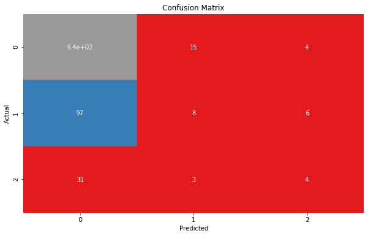

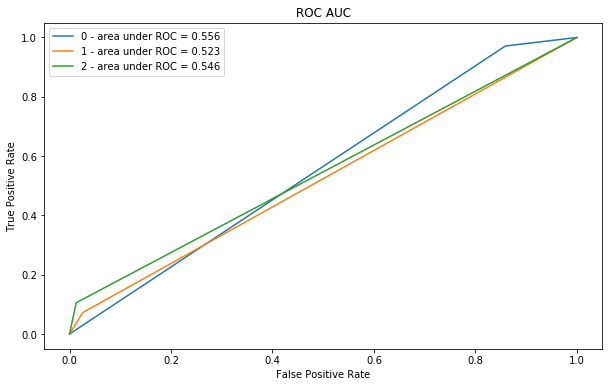

```python
model_scoring = model_eval(bagg["model"], X_test_scaled, y_test)
scores["Bagging Classifier | Multi"] = {"Accuracy": model_scoring[0],
                             "ROC": model_scoring[1],
                             "F1-Score": model_scoring[2]}
```

### Bagging Classifier (with PCA 4D)

```python
bagg_params = {
    'clf__max_samples': [0.3, 0.5, 0.7, 1.0],
    'clf__bootstrap': [True, False],
    'clf__bootstrap_features': [True, False]
}

bagg = Modeler(BaggingClassifier, X_train_scaled, y_train, X_cv, y_cv, bagg_params, scale=True, pca=4)
```

```
Best Parameters for model: {'bootstrap': False, 'bootstrap_features': True, 'max_samples': 0.5}
```

[output not shown]

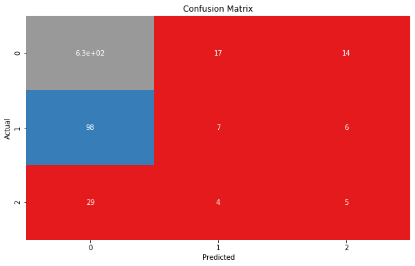

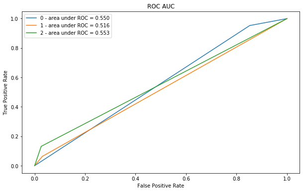

```python
model_scoring = model_eval(bagg["model"], X_test_scaled, y_test)

scores["Bagging Classifier | Multi | PCA"] = {"Accuracy": model_scoring[0],
                             "ROC": model_scoring[1],
                             "F1-Score": model_scoring[2]}
model_scoring
```

## Binary-Classifiers

```python
# We do not need confusing variables such as the class name; We can use it as an index or leave it.
X_binary = df.iloc[:, 1:-2]
y_binary = df["bugs"]

# Warning: Don't Run Twice
y_binary = y_binary.replace(y_binary.where(y_binary > 1), 1)

print("X:", X.shape)
print("y:", y.shape)
```

```
X: (5371, 17)
y: (5371,)
```

```
Classes: [0, 1]
Counts: [4518, 853]
```

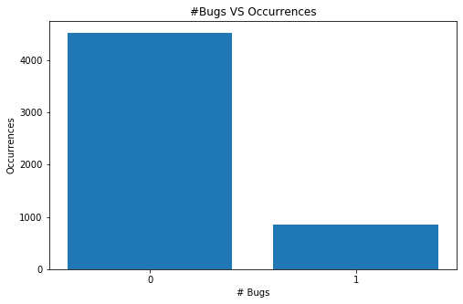

```python
unique, counts = np.unique(y_binary, return_counts=True)
print("Classes:", unique.tolist())
print("Counts:", counts.tolist())

plt.bar(unique, counts)
plt.title("#Bugs VS Occurrences")
plt.xticks(range(len(unique)))
plt.ylabel("Occurrences")
plt.xlabel("# Bugs");
```

```python
from sklearn.model_selection import train_test_split
X_train, X_test, y_train, y_test = train_test_split(X_binary, y_binary, test_size=0.3)
X_cv, X_test, y_cv, y_test = train_test_split(X_test, y_test, test_size=0.5)
print("Train:", X_train.shape, y_train.shape,
      "Test:", X_test.shape, y_test.shape,
      "Cross Validation", X_cv.shape, y_cv.shape)

X_train_scaled = pd.DataFrame(StandardScaler().fit_transform(X_train.values), columns=X_train.columns, index=X_train.index)
X_test_scaled = pd.DataFrame(StandardScaler().fit_transform(X_test.values), columns=X_test.columns, index=X_test.index)
```

```
Train: (3759, 17) (3759,) Test: (806, 17) (806,) Cross Validation (806, 17) (806,)
```

#### Warning: X_train, X_test,..., y_cv. has been overridden

### AdaBoost

```python
# AdaBoostClassifier
ada_params = {
    'clf__learning_rate': [0.1, 0.5, 1.0],
    'clf__n_estimators': [100, 200]
}

ada = Modeler(AdaBoostClassifier, X_train_scaled, y_train, X_cv, y_cv, ada_params, scale=True, n_jobs=False)
```

```
Best Parameters for model: {'learning_rate': 0.1, 'n_estimators': 100}
```

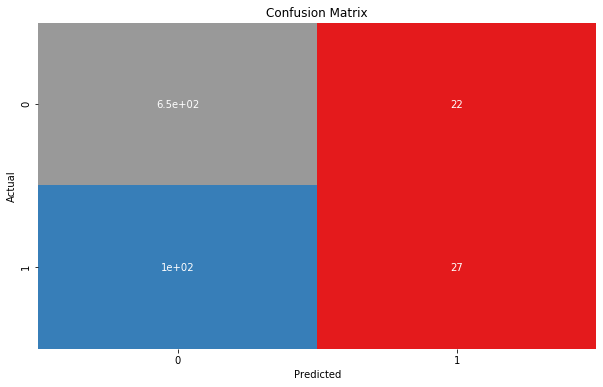

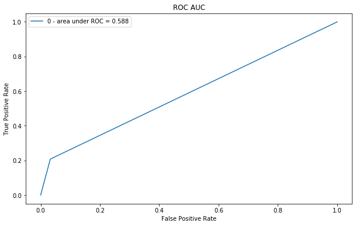

```python
model_scoring = model_eval(ada["model"], X_test_scaled, y_test, multi=False)
scores["AdaBoost Classifier | Binary"] = {"Accuracy": model_scoring[0],
                             "ROC": model_scoring[1],
                             "F1-Score": model_scoring[2]}
```

### Support-Vector Machine

```python
# SVC()
svc_params = {
    'clf__C': [0.1, 1, 10],
    'clf__kernel': ['linear', 'rbf'],
    'clf__gamma':[1, 0.01, 0.001]
}

svc = Modeler(SVC, X_train_scaled, y_train, X_cv, y_cv, svc_params, scale=True, n_jobs=False)
```

```
Best Parameters for model: {'C': 10, 'gamma': 0.01, 'kernel': 'rbf'}
```

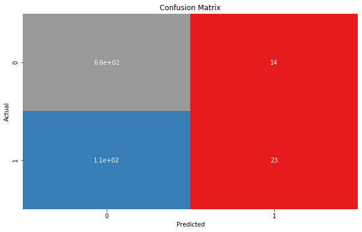

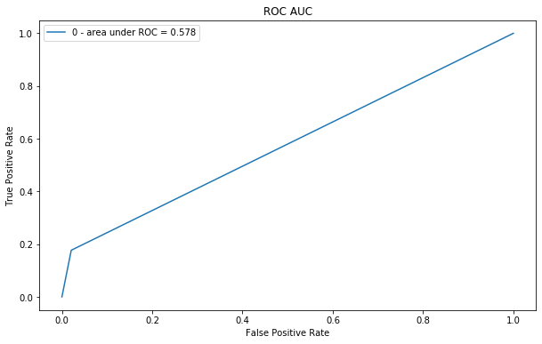

```python
model_scoring = model_eval(svc["model"], X_test_scaled, y_test, multi=False)
scores["Support-Vector Machine | Binary"] = {"Accuracy": model_scoring[0],
                             "ROC": model_scoring[1],
                             "F1-Score": model_scoring[2]}
```

### Bagging Classifier

```python
bagg_params = {
    'clf__max_samples': [0.3, 0.5, 0.7, 1.0],
    'clf__bootstrap': [True, False],
    'clf__bootstrap_features': [True, False]
}

bagg = Modeler(BaggingClassifier, X_train_scaled, y_train, X_cv, y_cv, bagg_params, scale=True)
```

```
Best Parameters for model: {'bootstrap': True, 'bootstrap_features': True, 'max_samples': 0.5}
```

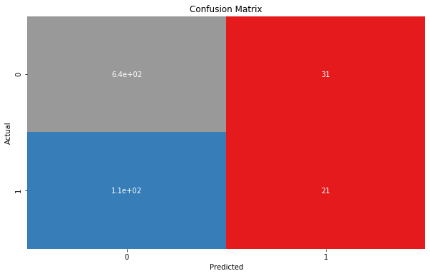

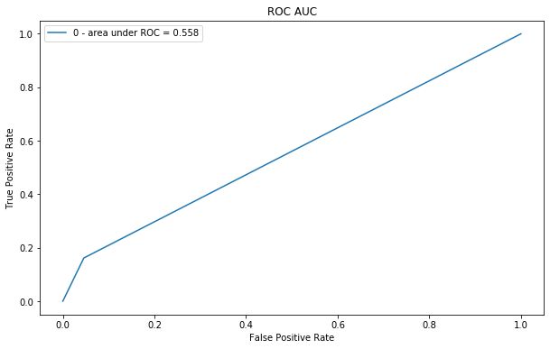

```python
model_scoring = model_eval(bagg["model"], X_test_scaled, y_test, multi=False)
scores["Bagging Classifier | Binary"] = {"Accuracy": model_scoring[0],
                             "ROC": model_scoring[1],
                             "F1-Score": model_scoring[2]}
```

## Neural Network

```python
from keras.models import Sequential
from keras.layers import Dense
from keras import optimizers
```

```python
def nn_modeler(input_dim, layer_1_dim, layer_2_dim, lr, out):
    model = Sequential()
    model.add(Dense(layer_1_dim, input_dim=input_dim, activation='relu'))
    model.add(Dense(layer_2_dim, activation='relu'))
    model.add(Dense(out, activation='sigmoid'))
    SGD = optimizers.SGD(lr=lr)

    model.compile(loss='binary_crossentropy', optimizer = SGD)
    return model
```

```python
NN_scores = {}
n_split=3
epochs = [30, 50] # Take a lot of time
batch_sizes = [32, 64] # Take a lot of time
first_layers = [30, 50]
second_layers = [10, 20]
lrs = [0.001, 0.1]
iters = 0
for epoch in epochs:
    for batch_size in batch_sizes:
        for first_layer in first_layers:
            for second_layer in second_layers:
                for lr in lrs:
                    # K-FOLDS
                    fcnn = None
                    accs = []
                    aurocs = []
                    f1s = []
                    for train_indicies, test_indicies in StratifiedKFold(n_split).split(X_cv, y_cv):
                        X_train_fold, y_train_fold, X_test_fold, y_test_fold = X_cv.iloc[train_indicies], y_cv.iloc[train_indicies], X_cv.iloc[test_indicies], y_cv.iloc[test_indicies]
                        X_train_fold = pd.DataFrame(StandardScaler().fit_transform(X_train_fold.values), columns=X_train_fold.columns, index=X_train_fold.index)
                        X_test_fold = pd.DataFrame(StandardScaler().fit_transform(X_test_fold.values), columns=X_test_fold.columns, index=X_test_fold.index)

                        fcnn = nn_modeler(17, first_layer, second_layer, lr, 1)
                        fcnn.fit(X_train_fold, y_train_fold, epochs=epoch, batch_size=batch_size, verbose=False)
                        model_scoring = model_eval(fcnn, X_test_scaled, y_test, plot_auc=False, plot_conf=False, prop=True)
                        accs.append(model_scoring[0])
                        aurocs.append(model_scoring[1])
                        f1s.append(model_scoring[2])

                    info = "ep:" + str(epoch) + " bs:" + str(batch_size) + " f_lyr:" + str(first_layer) + " s_lyr:" + str(second_layer) + " lr:" + str(lr)

                    NN_scores[info] = {"Accuracy": np.mean(accs), "ROC": np.mean(aurocs), "F1": np.mean(f1s)}
                    iters +=1
                    print(str(iters) +'..', end='')
```

```
1..2..3..4..5..6..7..8..9..10..11..12..13..14..15..16..17..18..19..20..21..22..23..24..25..26..27..28..29..30..31..32..
```

```python
NN_scores = pd.DataFrame.from_dict(NN_scores).T
NN_scores = NN_scores.sort_values('ROC', ascending=False)
```

```python
NN_scores.iloc[:10,:]
```

|  | Accuracy | ROC | F1 |
| --- | --- | --- | --- |
| ep:30 bs:32 f_lyr:50 s_lyr:10 lr:0.1 | 0.850289 | 0.609418 | 0.634376 |
| ep:50 bs:32 f_lyr:50 s_lyr:20 lr:0.1 | 0.850703 | 0.605523 | 0.629998 |
| ep:30 bs:32 f_lyr:30 s_lyr:20 lr:0.1 | 0.849462 | 0.603748 | 0.627612 |
| ep:50 bs:32 f_lyr:30 s_lyr:20 lr:0.1 | 0.844913 | 0.598964 | 0.619995 |
| ep:50 bs:64 f_lyr:50 s_lyr:20 lr:0.1 | 0.847395 | 0.593195 | 0.614819 |
| ep:30 bs:64 f_lyr:50 s_lyr:20 lr:0.1 | 0.847808 | 0.592406 | 0.613290 |
| ep:50 bs:64 f_lyr:30 s_lyr:20 lr:0.1 | 0.846567 | 0.589596 | 0.610000 |
| ep:50 bs:64 f_lyr:30 s_lyr:10 lr:0.1 | 0.846154 | 0.589349 | 0.608987 |
| ep:50 bs:64 f_lyr:50 s_lyr:10 lr:0.1 | 0.842018 | 0.588955 | 0.607403 |
| ep:30 bs:64 f_lyr:50 s_lyr:10 lr:0.1 | 0.846567 | 0.584418 | 0.603222 |

##### Best Params

- Epochs: 30
- Batch Size: 32
- First Hidden Layer neurons: 50
- Second Hidden Layer neurons: 10
- Learning Rate: 0.1

```python
fcnn = nn_modeler(17, 50, 10, 0.1, 1)
fcnn.fit(X_train_scaled, y_train, epochs=30, batch_size=32, verbose=False)

model_scoring = model_eval(fcnn, X_test_scaled, y_test, plot_auc=False, plot_conf=False, prop=True)


scores["Neural Network | Binary"] = {"Accuracy": model_scoring[0],
                             "ROC": model_scoring[1],
                             "F1-Score": model_scoring[2]}
```

#### Note:

All models achieved a similar or less auc rocs/f1 without scaling (tried it for a sanity check)

```python
score_df = pd.DataFrame.from_dict(scores).T
score_df= score_df.sort_values('ROC', ascending=False)
```

```python
score_df
```

|  | Accuracy | ROC | F1-Score |
| --- | --- | --- | --- |
| Neural Network \| Binary | 0.841191 | 0.610207 | 0.631506 |
| AdaBoost Classifier \| Binary | 0.844913 | 0.587574 | 0.607223 |
| Support-Vector Machine \| Binary | 0.849876 | 0.578107 | 0.595856 |
| Random Forest \| Multi | 0.815136 | 0.557972 | 0.414003 |
| Bagging Classifier \| Binary | 0.826303 | 0.557840 | 0.566434 |
| K-Nearest Neighbor \| Multi | 0.820099 | 0.547559 | 0.399570 |
| Bagging Classifier \| Multi | 0.806452 | 0.541739 | 0.389111 |
| Bagging Classifier \| Multi \| PCA | 0.791563 | 0.539809 | 0.382464 |
| Dummy Classifier \| Multi | 0.815136 | 0.500000 | 0.299385 |
| Dummy Classifier \| Binary | 0.815136 | 0.500000 | 0.299385 |
| K-Means \| Multi | 0.076923 | 0.464229 | 0.029483 |

# Data-Driven Model Optimization

## Under Sampling

Redcuing the number of samples in the majority class randomly so that the two classes are balanced and then testing it on an imbalanced real-world-like dataset (test set)

#### Neural Network

This modle was also trained on a PCAed training set with/out under-sampling

```python
X_train_under_sampled, y_train_under_sampled = under_sample(X_train_scaled, y_train, n=(y_train==1).sum())

# print((y_train_under_sampled == 1).sum())
# print((y_train_under_sampled == 0).sum())

fcnn = nn_modeler(17, 50, 10, 0.1, 1)
fcnn.fit(X_train_under_sampled, y_train_under_sampled, epochs=30, batch_size=32, verbose=False)
```

```
<keras.callbacks.History at 0x258169dfcc0>
```

```python
model_scoring = model_eval(fcnn, X_test_scaled, y_test, plot_auc=False, plot_conf=False, prop=True)
scores["Neural Network | Binary | USam"] = {"Accuracy": model_scoring[0],
                             "ROC": model_scoring[1],
                             "F1-Score": model_scoring[2]}
model_scoring
```

```
[0.7320099255583127, 0.7159763313609468, 0.638456937799043]
```

#### AdaBoost

```python
# X_cv_scaled = pd.DataFrame(StandardScaler().fit_transform(X_cv.values), columns=X_cv.columns, index=X_cv.index)
X_cv_under_sampled, y_cv_under_sampled = under_sample(X_cv, y_cv, n=(y_cv == 1).sum())

ada_params = {
    'clf__learning_rate': [0.1, 0.5, 1.0],
    'clf__n_estimators': [100, 200]
}

ada = Modeler(AdaBoostClassifier, X_train_under_sampled, y_train_under_sampled, X_cv_under_sampled, y_cv_under_sampled,
              ada_params, scale=True, n_jobs=False)
```

```
Best Parameters for model: {'learning_rate': 0.1, 'n_estimators': 200}
```

```python
model_scoring = model_eval(ada["model"], X_test_scaled, y_test, multi=False, plot_auc=False, plot_conf=False)
scores["AdaBoost Classifier | Binary | Usam"] = {"Accuracy": model_scoring[0],
                             "ROC": model_scoring[1],
                             "F1-Score": model_scoring[2]}
model_scoring
```

```
[0.7196029776674938, 0.714792899408284, 0.6303802605413742]
```

#### Bagging Classifier

```python
bagg_params = {
    'clf__max_samples': [0.3, 0.5, 0.7, 1.0],
    'clf__bootstrap': [True, False],
    'clf__bootstrap_features': [True, False]
}

bagg = Modeler(BaggingClassifier, X_train_under_sampled, y_train_under_sampled, X_cv_under_sampled, y_cv_under_sampled,
               bagg_params, scale=True)
```

```
Best Parameters for model: {'bootstrap': True, 'bootstrap_features': False, 'max_samples': 0.5}
```

```python
model_scoring = model_eval(bagg["model"], X_test_scaled, y_test, multi=False, plot_auc=False, plot_conf=False)
scores["Bagging Classifier | Binary | Usam"] = {"Accuracy": model_scoring[0],
                             "ROC": model_scoring[1],
                             "F1-Score": model_scoring[2]}
model_scoring
```

```
[0.7245657568238213, 0.6773668639053255, 0.6177973342447027]
```

```python
score_df = pd.DataFrame.from_dict(scores).T
score_df= score_df.sort_values('ROC', ascending=False)
```

```python
score_df
```

[output not shown]

## Over Sampling

```python
from imblearn.over_sampling import SMOTE
X_train_over_sampled, y_train_over_sampled = SMOTE().fit_sample(X_train_scaled, y_train)
X_cv_over_sampled, y_cv_over_sampled = SMOTE().fit_sample(X_cv, y_cv)
```

```python
# print((y_train_over_sampled == 1).sum())
# print((y_train_over_sampled == 0).sum())

# print((y_cv_over_sampled == 1).sum())
# print((y_cv_over_sampled == 0).sum())

X_train_over_sampled = pd.DataFrame(X_train_over_sampled)
X_cv_over_sampled = pd.DataFrame(X_cv_over_sampled)

y_train_over_sampled = pd.Series(y_train_over_sampled)
y_cv_over_sampled = pd.Series(y_cv_over_sampled)
```

#### Neural Network

```python
fcnn = nn_modeler(17, 50, 10, 0.1, 1)
fcnn.fit(X_train_scaled, y_train, epochs=30, batch_size=32, verbose=False)
```

```
<keras.callbacks.History at 0x2581a5390b8>
```

```python
model_scoring = model_eval(fcnn, X_test_scaled, y_test, plot_auc=False, plot_conf=False, prop=True)
scores["Neural Network | Binary | OSam"] = {"Accuracy": model_scoring[0],
                             "ROC": model_scoring[1],
                             "F1-Score": model_scoring[2]}
model_scoring
```

```
[0.8362282878411911, 0.6196745562130178, 0.6386386794375383]
```

#### AdaBoost

```python
ada_params = {
    'clf__learning_rate': [0.1, 0.5, 1.0],
    'clf__n_estimators': [100, 200]
}

ada = Modeler(AdaBoostClassifier, X_train_over_sampled, y_train_over_sampled, X_cv_over_sampled, y_cv_over_sampled,
              ada_params, scale=True, n_jobs=False)
```

```
Best Parameters for model: {'learning_rate': 1.0, 'n_estimators': 200}
```

```python
model_scoring = model_eval(ada["model"], X_test_scaled, y_test, multi=False, plot_auc=False, plot_conf=False)
scores["AdaBoost Classifier | Binary | Osam"] = {"Accuracy": model_scoring[0],
                             "ROC": model_scoring[1],
                             "F1-Score": model_scoring[2]}
model_scoring
```

```
[0.3014888337468983, 0.5587278106508876, 0.3014877585105482]
```

#### Bagging Classifier

```python
bagg_params = {
    'clf__max_samples': [0.3, 0.5, 0.7, 1.0],
    'clf__bootstrap': [True, False],
    'clf__bootstrap_features': [True, False]
}

bagg = Modeler(BaggingClassifier, X_train_over_sampled, y_train_over_sampled, X_cv_over_sampled, y_cv_over_sampled,
               bagg_params, scale=True)
```

```
Best Parameters for model: {'bootstrap': False, 'bootstrap_features': True, 'max_samples': 1.0}
```

```python
model_scoring = model_eval(bagg["model"], X_test_scaled, y_test, multi=False, plot_auc=False, plot_conf=False)
scores["Bagging Classifier | Binary | Osam"] = {"Accuracy": model_scoring[0],
                             "ROC": model_scoring[1],
                             "F1-Score": model_scoring[2]}
model_scoring
```

```
[0.358560794044665, 0.5026627218934911, 0.34791174707797945]
```

```python
score_df = pd.DataFrame.from_dict(scores).T
score_df= score_df.sort_values('ROC', ascending=False)
```

```python
score_df
```

[output not shown]

## With Feature Selection

#### Refer back to feature selection above, features selected were:

```
- rfc
- cbo
- fanOut
- wmc
- numberOfLinesOfCode
```

```python
X_train_scaled_featured = X_train_scaled[['rfc', 'cbo', 'fanOut', 'wmc', 'numberOfLinesOfCode']]
X_test_scaled_featured = X_test_scaled[['rfc', 'cbo', 'fanOut', 'wmc', 'numberOfLinesOfCode']]
X_cv_featured = X_cv[['rfc', 'cbo', 'fanOut', 'wmc', 'numberOfLinesOfCode']]

X_train_scaled_featured_underS = X_train_under_sampled[['rfc', 'cbo', 'fanOut', 'wmc', 'numberOfLinesOfCode']]
X_cv_featured_underS = X_cv_under_sampled[['rfc', 'cbo', 'fanOut', 'wmc', 'numberOfLinesOfCode']]
```

#### Neural Network

```python
fcnn = nn_modeler(5, 50, 10, 0.1, 1)
fcnn.fit(X_train_scaled_featured, y_train, epochs=30, batch_size=32, verbose=False)
```

```
<keras.callbacks.History at 0x2581affb828>
```

```python
model_scoring = model_eval(fcnn, X_test_scaled_featured, y_test, plot_auc=False, plot_conf=False, prop=True)
scores["Neural Network | Binary | Featured"] = {"Accuracy": model_scoring[0],
                             "ROC": model_scoring[1],
                             "F1-Score": model_scoring[2]}
model_scoring
```

```
[0.847394540942928, 0.5579881656804734, 0.5660122135399567]
```

```python
ada_params = {
    'clf__learning_rate': [0.1, 0.5, 1.0],
    'clf__n_estimators': [100, 200]
}

ada = Modeler(AdaBoostClassifier, X_train_scaled_featured, y_train, X_cv_featured, y_cv,
              ada_params, scale=True, n_jobs=False)
```

```
Best Parameters for model: {'learning_rate': 0.1, 'n_estimators': 100}
```

```python
model_scoring = model_eval(ada["model"], X_test_scaled_featured, y_test, multi=False, plot_auc=False, plot_conf=False)
scores["AdaBoost Classifier | Binary | Featured"] = {"Accuracy": model_scoring[0],
                             "ROC": model_scoring[1],
                             "F1-Score": model_scoring[2]}
model_scoring
```

```
[0.847394540942928, 0.5766272189349112, 0.5934751319366703]
```

```python
bagg_params = {
    'clf__max_samples': [0.3, 0.5, 0.7, 1.0],
    'clf__bootstrap': [True, False],
    'clf__bootstrap_features': [True, False]
}

bagg = Modeler(BaggingClassifier, X_train_scaled_featured, y_train, X_cv_featured, y_cv,
               bagg_params, scale=True)
```

```
Best Parameters for model: {'bootstrap': False, 'bootstrap_features': False, 'max_samples': 0.3}
```

```python
model_scoring = model_eval(bagg["model"], X_test_scaled_featured, y_test, multi=False, plot_auc=False, plot_conf=False)
scores["Bagging Classifier | Binary | Featured"] = {"Accuracy": model_scoring[0],
                             "ROC": model_scoring[1],
                             "F1-Score": model_scoring[2]}
model_scoring
```

```
[0.8411910669975186, 0.5853550295857988, 0.6035964035964035]
```

#### Feature Selection with Under Sampling

```python
# X_train_scaled_featured_underS
# X_cv_featured_underS

fcnn = nn_modeler(5, 50, 10, 0.1, 1)
fcnn.fit(X_train_scaled_featured_underS, y_train_under_sampled, epochs=30, batch_size=32, verbose=False)
```

```
<keras.callbacks.History at 0x2581afcfda0>
```

```python
model_scoring = model_eval(fcnn, X_test_scaled_featured, y_test, plot_auc=False, plot_conf=False, prop=True)
scores["Neural Network | Binary | Featured | USam"] = {"Accuracy": model_scoring[0],
                             "ROC": model_scoring[1],
                             "F1-Score": model_scoring[2]}
model_scoring
```

```
[0.7481389578163772, 0.7100591715976332, 0.6459611335787099]
```

```python
ada_params = {
    'clf__learning_rate': [0.1, 0.5, 1.0],
    'clf__n_estimators': [100, 200]
}

ada = Modeler(AdaBoostClassifier, X_train_scaled_featured_underS, y_train_under_sampled, X_cv_featured_underS, y_cv_under_sampled,
              ada_params, scale=True, n_jobs=False)
```

```
Best Parameters for model: {'learning_rate': 0.1, 'n_estimators': 100}
```

```python
model_scoring = model_eval(ada["model"], X_test_scaled_featured, y_test, multi=False, plot_auc=False, plot_conf=False)
scores["AdaBoost Classifier | Binary | Featured | USam"] = {"Accuracy": model_scoring[0],
                             "ROC": model_scoring[1],
                             "F1-Score": model_scoring[2]}
model_scoring
```

```
[0.7617866004962779, 0.7026627218934911, 0.651082251082251]
```

```python
bagg_params = {
    'clf__max_samples': [0.3, 0.5, 0.7, 1.0],
    'clf__bootstrap': [True, False],
    'clf__bootstrap_features': [True, False]
}

bagg = Modeler(BaggingClassifier, X_train_scaled_featured_underS, y_train_under_sampled, X_cv_featured_underS, y_cv_under_sampled,
               bagg_params, scale=True)
```

```
Best Parameters for model: {'bootstrap': True, 'bootstrap_features': True, 'max_samples': 1.0}
```

```python
model_scoring = model_eval(bagg["model"], X_test_scaled_featured, y_test, multi=False, plot_auc=False, plot_conf=False)
scores["Bagging Classifier | Binary | Featured | USam"] = {"Accuracy": model_scoring[0],
                             "ROC": model_scoring[1],
                             "F1-Score": model_scoring[2]}
model_scoring
```

```
[0.6985111662531017, 0.6338757396449703, 0.5839067615310586]
```

# Model Quality Metric Table

```python
score_df = pd.DataFrame.from_dict(scores).T
```

```python
multi_clf_scores = score_df[(score_df.index.str.contains('Multi'))]
binary_clf_scores = score_df[(score_df.index.str.contains('Binary') == True)]
```

#### Base-Line

```python
score_df[(score_df.index.str.contains('Dummy'))]
```

|  | Accuracy | ROC | F1-Score |
| --- | --- | --- | --- |
| Dummy Classifier \| Multi | 0.815136 | 0.5 | 0.299385 |
| Dummy Classifier \| Binary | 0.815136 | 0.5 | 0.299385 |

## Multi-Classifiers

#### By accuracy

```python
multi_clf_scores.sort_values('Accuracy', ascending=False)
```

|  | Accuracy | ROC | F1-Score |
| --- | --- | --- | --- |
| K-Nearest Neighbor \| Multi | 0.820099 | 0.547559 | 0.399570 |
| Dummy Classifier \| Multi | 0.815136 | 0.500000 | 0.299385 |
| Random Forest \| Multi | 0.815136 | 0.557972 | 0.414003 |
| Bagging Classifier \| Multi | 0.806452 | 0.541739 | 0.389111 |
| Bagging Classifier \| Multi \| PCA | 0.791563 | 0.539809 | 0.382464 |
| K-Means \| Multi | 0.076923 | 0.464229 | 0.029483 |

#### By ROC

```python
multi_clf_scores.sort_values('ROC', ascending=False)
```

|  | Accuracy | ROC | F1-Score |
| --- | --- | --- | --- |
| Random Forest \| Multi | 0.815136 | 0.557972 | 0.414003 |
| K-Nearest Neighbor \| Multi | 0.820099 | 0.547559 | 0.399570 |
| Bagging Classifier \| Multi | 0.806452 | 0.541739 | 0.389111 |
| Bagging Classifier \| Multi \| PCA | 0.791563 | 0.539809 | 0.382464 |
| Dummy Classifier \| Multi | 0.815136 | 0.500000 | 0.299385 |
| K-Means \| Multi | 0.076923 | 0.464229 | 0.029483 |

#### By F1-Score

```python
multi_clf_scores.sort_values('F1-Score', ascending=False)
```

|  | Accuracy | ROC | F1-Score |
| --- | --- | --- | --- |
| Random Forest \| Multi | 0.815136 | 0.557972 | 0.414003 |
| K-Nearest Neighbor \| Multi | 0.820099 | 0.547559 | 0.399570 |
| Bagging Classifier \| Multi | 0.806452 | 0.541739 | 0.389111 |
| Bagging Classifier \| Multi \| PCA | 0.791563 | 0.539809 | 0.382464 |
| Dummy Classifier \| Multi | 0.815136 | 0.500000 | 0.299385 |
| K-Means \| Multi | 0.076923 | 0.464229 | 0.029483 |

#### Best in Accuracy

```python
multi_clf_scores.sort_values('Accuracy', ascending=False).iloc[:1,:]
```

|  | Accuracy | ROC | F1-Score |
| --- | --- | --- | --- |
| K-Nearest Neighbor \| Multi | 0.820099 | 0.547559 | 0.39957 |

#### Best in ROC

```python
multi_clf_scores.sort_values('ROC', ascending=False).iloc[:1,:]
```

|  | Accuracy | ROC | F1-Score |
| --- | --- | --- | --- |
| Random Forest \| Multi | 0.815136 | 0.557972 | 0.414003 |

#### Best in F1-Score

```python
multi_clf_scores.sort_values('F1-Score', ascending=False).iloc[:1,:]
```

|  | Accuracy | ROC | F1-Score |
| --- | --- | --- | --- |
| Random Forest \| Multi | 0.815136 | 0.557972 | 0.414003 |

## Binary Classifiers

#### By Accuracy

```python
binary_clf_scores.sort_values('Accuracy', ascending=False)
```

|  | Accuracy | ROC | F1-Score |
| --- | --- | --- | --- |
| Support-Vector Machine \| Binary | 0.849876 | 0.578107 | 0.595856 |
| AdaBoost Classifier \| Binary \| Featured | 0.847395 | 0.576627 | 0.593475 |
| Neural Network \| Binary \| Featured | 0.847395 | 0.557988 | 0.566012 |
| AdaBoost Classifier \| Binary | 0.844913 | 0.587574 | 0.607223 |
| Neural Network \| Binary | 0.841191 | 0.610207 | 0.631506 |
| Bagging Classifier \| Binary \| Featured | 0.841191 | 0.585355 | 0.603596 |
| Neural Network \| Binary \| OSam | 0.836228 | 0.619675 | 0.638639 |
| Bagging Classifier \| Binary | 0.826303 | 0.557840 | 0.566434 |
| Dummy Classifier \| Binary | 0.815136 | 0.500000 | 0.299385 |
| AdaBoost Classifier \| Binary \| Featured \| USam | 0.761787 | 0.702663 | 0.651082 |
| Neural Network \| Binary \| Featured \| USam | 0.748139 | 0.710059 | 0.645961 |
| Neural Network \| Binary \| USam | 0.732010 | 0.715976 | 0.638457 |
| Bagging Classifier \| Binary \| Usam | 0.724566 | 0.677367 | 0.617797 |
| AdaBoost Classifier \| Binary \| Usam | 0.719603 | 0.714793 | 0.630380 |
| Bagging Classifier \| Binary \| Featured \| USam | 0.698511 | 0.633876 | 0.583907 |
| Bagging Classifier \| Binary \| Osam | 0.358561 | 0.502663 | 0.347912 |
| AdaBoost Classifier \| Binary \| Osam | 0.301489 | 0.558728 | 0.301488 |

#### By ROC

```python
binary_clf_scores.sort_values('ROC', ascending=False)
```

|  | Accuracy | ROC | F1-Score |
| --- | --- | --- | --- |
| Neural Network \| Binary \| USam | 0.732010 | 0.715976 | 0.638457 |
| AdaBoost Classifier \| Binary \| Usam | 0.719603 | 0.714793 | 0.630380 |
| Neural Network \| Binary \| Featured \| USam | 0.748139 | 0.710059 | 0.645961 |
| AdaBoost Classifier \| Binary \| Featured \| USam | 0.761787 | 0.702663 | 0.651082 |
| Bagging Classifier \| Binary \| Usam | 0.724566 | 0.677367 | 0.617797 |
| Bagging Classifier \| Binary \| Featured \| USam | 0.698511 | 0.633876 | 0.583907 |
| Neural Network \| Binary \| OSam | 0.836228 | 0.619675 | 0.638639 |
| Neural Network \| Binary | 0.841191 | 0.610207 | 0.631506 |
| AdaBoost Classifier \| Binary | 0.844913 | 0.587574 | 0.607223 |
| Bagging Classifier \| Binary \| Featured | 0.841191 | 0.585355 | 0.603596 |
| Support-Vector Machine \| Binary | 0.849876 | 0.578107 | 0.595856 |
| AdaBoost Classifier \| Binary \| Featured | 0.847395 | 0.576627 | 0.593475 |
| AdaBoost Classifier \| Binary \| Osam | 0.301489 | 0.558728 | 0.301488 |
| Neural Network \| Binary \| Featured | 0.847395 | 0.557988 | 0.566012 |
| Bagging Classifier \| Binary | 0.826303 | 0.557840 | 0.566434 |
| Bagging Classifier \| Binary \| Osam | 0.358561 | 0.502663 | 0.347912 |
| Dummy Classifier \| Binary | 0.815136 | 0.500000 | 0.299385 |

#### By F1-Score

```python
binary_clf_scores.sort_values('F1-Score', ascending=False)
```

|  | Accuracy | ROC | F1-Score |
| --- | --- | --- | --- |
| AdaBoost Classifier \| Binary \| Featured \| USam | 0.761787 | 0.702663 | 0.651082 |
| Neural Network \| Binary \| Featured \| USam | 0.748139 | 0.710059 | 0.645961 |
| Neural Network \| Binary \| OSam | 0.836228 | 0.619675 | 0.638639 |
| Neural Network \| Binary \| USam | 0.732010 | 0.715976 | 0.638457 |
| Neural Network \| Binary | 0.841191 | 0.610207 | 0.631506 |
| AdaBoost Classifier \| Binary \| Usam | 0.719603 | 0.714793 | 0.630380 |
| Bagging Classifier \| Binary \| Usam | 0.724566 | 0.677367 | 0.617797 |
| AdaBoost Classifier \| Binary | 0.844913 | 0.587574 | 0.607223 |
| Bagging Classifier \| Binary \| Featured | 0.841191 | 0.585355 | 0.603596 |
| Support-Vector Machine \| Binary | 0.849876 | 0.578107 | 0.595856 |
| AdaBoost Classifier \| Binary \| Featured | 0.847395 | 0.576627 | 0.593475 |
| Bagging Classifier \| Binary \| Featured \| USam | 0.698511 | 0.633876 | 0.583907 |
| Bagging Classifier \| Binary | 0.826303 | 0.557840 | 0.566434 |
| Neural Network \| Binary \| Featured | 0.847395 | 0.557988 | 0.566012 |
| Bagging Classifier \| Binary \| Osam | 0.358561 | 0.502663 | 0.347912 |
| AdaBoost Classifier \| Binary \| Osam | 0.301489 | 0.558728 | 0.301488 |
| Dummy Classifier \| Binary | 0.815136 | 0.500000 | 0.299385 |

#### Best in Accuracy

```python
binary_clf_scores.sort_values('Accuracy', ascending=False).iloc[:1,:]
```

|  | Accuracy | ROC | F1-Score |
| --- | --- | --- | --- |
| Support-Vector Machine \| Binary | 0.849876 | 0.578107 | 0.595856 |

#### Best in ROC

```python
binary_clf_scores.sort_values('ROC', ascending=False).iloc[:1,:]
```

|  | Accuracy | ROC | F1-Score |
| --- | --- | --- | --- |
| Neural Network \| Binary \| USam | 0.73201 | 0.715976 | 0.638457 |

#### Best in F1-Score

```python
binary_clf_scores.sort_values('F1-Score', ascending=False).iloc[:1,:]
```

|  | Accuracy | ROC | F1-Score |
| --- | --- | --- | --- |
| AdaBoost Classifier \| Binary \| Featured \| USam | 0.761787 | 0.702663 | 0.651082 |

### Notes

##### F1-Score uses macro-averaging:

This is a way to ensure that we're giving a fair weight (i.e. decrease the total metric score when the lower-in-size class is misclassified). This choice was made to ensure that classifying 0 bugs when there are actually 1 or more bugs is extremely unwanted in the real world (e.g. predicting NO cancerous cells - majority - when there're cancerous cells is considered a false-negative which is dangerous). Here, the negative class is having a bug > 0. Releasing the software with a false knowledge that there are no bugs creats an issue, in a sense, Misclassifying a negative sample would be detrimental to business.

##### PCA:

Note that most of the models were trained with/out pca but not added due to the large number of unending combinations (7 classifiers x hyper-parameter tuning combinations x 2 (for pca) x 2 (for umap)).

##### Under Sampling

Under sampling is a technique in which we randomly draw without replacement **n** sample from the majority class where **n = full samples in the minority class** to solve the imbalance in the training dataset where the classifier can focus on both classes without falling into a biased measurements towards one class over another. Then we test it on an unchaged real-world imbalanced dataset and check whether the model has achieved an accepted classifications for each class. we can see the improvement after applying this technique.

##### Over Sampling

The opposite of under sampling in which we focus our attention on the less abundant class and synthesize some extra points for it. This is done when we talk about SMOT (Synthetic Minority Over-sampling Technique) by taking a sample from the minority class and get the k-nearest neighbors of that sample, draw a vector between the sample and the k-nearest point, multiply it by a random number and add this point to the dataset.

##### AdaBoost

This is one of the classifiers that also helps with this imbalanced dataset as it uses a technique in which it adds more weight to the samples that were incorrectly classified after the initialization of equal weights for all samples (classifier's weight alpha that is based on the error rate of a chosen sample). Now with the class that was incorrectly classified in this imbalanced dataset, the model will focus on these ones more.

# Extra

Now let's try to intentionally increase the roc and accuracy and leave f1-score out of the equation, I really want to emphasize more on the importance of f1-score when we're dealing with an imbalanced data and we care about recall

\begin{equation*} {F_β} = (1 + β^2) + \frac{precision * recall}{(β^2 * precision + recall)} \end{equation*}

This is the harmonic mean which gives a measure of how good the classifier is w.r.t precision and recall

${prediction} = {+}$ ${AND}$ ${actual} = {-}$

is more dangerous than:

${prediction} = {-}$ ${AND}$ ${actual} = {+}$

where positive = no bugs, and negative = bugs

#### This is a quick illustration of increasing the roc and accuracy

We are going to use an anamoly detection algorithm where it focuses only on the distribution of the dataset and predicts whether this is an outlier or inliner w.r.t a certain threshold

```python
from sklearn.ensemble import IsolationForest

isol_forest = IsolationForest(max_samples=X_train.shape[0], contamination=0.005)
isol_forest.fit(X_train, y_train)

preds = isol_forest.predict(X_test)
preds = np.asarray([1 if x == -1 else 0 for x in preds])

print("f1-score:", f1_score(preds, y_test) ,"%")
print("AUC-ROC: ", roc_auc_score(preds, y_test) ,"%")
print("Accuracy:", accuracy_score(preds, y_test) ,"%")
print("pred inliner:", sum(preds == 0))
print("pred outlier:", sum(preds == 1))
print("test inliner:", sum(y_test == 0))
print("test outlier:", sum(y_test == 1))
```

```
f1-score: 0.059259259259259255 %
AUC-ROC:  0.9208229426433916 %
Accuracy: 0.8424317617866005 %
pred inliner: 802
pred outlier: 4
test inliner: 675
test outlier: 131
```

```python
counter_1 = 0
for pred, act in zip(preds, y_test):
    if pred == act and pred == 1:
        counter_1+=1
print("number of 1's predicted accuratly: ", counter_1)
```

```
number of 1's predicted accuratly:  4
```

Now you can see how the roc fails in giving a good measure of how the model will behave in real life. This is what happens when we focus more (using f1-score compared to roc) on false negatives (predicting positive=0=no_bugs but actual is negative=1=bugs)